# GWAS datasets for FDR benchmarking

Keegan Korthauer

9/28/2017

### Summary

Here are the GWAS datasets we will use to benchmark the FDR methods. For each one we provide the script to download the data and read into R. We’d like to verify that each dataset contains the desired inputs:

- p-value
- effect size
- standard error
- additional covariates (optional)

Note that while running all the bash code in this document will download the data, some of it doesn’t seem to work properly with knitting (e.g. the ftp download in the second dataset), and I’m not committing the data itself to this repo. Run the bash code in the terminal separately to download the data yourself, and see the knitted `.html` document if you do not wish to download the datasets but still wish to see the output.

We’ll also run the benchmark methods on each dataset and report the number of discoveries for each one. At first, we’ll demo on just a **small subset of SNPs**, since the computation is time-intensive. After that is working smoothly, we’ll scale it up to the full set of SNPs.

### Workspace setup

To run the benchmark methods on the GWAS datasets, we’ll use some of the helper and wrapper functions from the simulated data analysis. We also create and source an analgous version of the `sim_runner` function to apply to the real data.

```r
# Note that swfdr package depends on R version 3.4 or higher
setwd("/n/irizarryfs01_backed_up/kkorthauer/FDR")
source("benchmark-fdr/simulation_studies/R/simulation-helpers.R")
source("benchmark-fdr/datasets/R/evaluation-helpers.R")
datdir <- "/n/irizarryfs01_backed_up/kkorthauer/FDR/DATA/GWAS/"
resdir <- "/n/irizarryfs01_backed_up/kkorthauer/FDR/RESULTS/GWAS/"

# wrangling & plotting tools
library(data.table)
library(readxl)
library(dplyr)
library(ggplot2)
library(cowplot)
library(UpSetR)

# benchmark methods
library(IHW)
library(ashr)
library(qvalue)
library(swfdr)
library(fdrtool)

# constant parameters (for UpSet Plots)
alpha.cutoff <- 0.05
```

### GWAS meta-analysis for BMI (included in Boca-Leek)

Here we download and analyze the GWAS BMI dataset analyzed in the Boca-Leek paper.

#### Data download

```bash
curl -O "http://portals.broadinstitute.org/collaboration/giant/images/3/3a/BMI.SNPadjSMK.zip"
```

Next we unzip the file, and delete the files we won’t use (they provide results subsetted by ancestry and sex), keeping only the file with all ancestries and both sexes `BMI.SNPadjSMK.CombinedSexes.AllAncestry.txt`. Note that it seems that the Boca-Leek paper actually used the ‘EuropeanOnly’ subset, but it’s not clear why (to me), and there’s no reason we need to do the same.

```bash
unzip BMI.SNPadjSMK.zip
rm BMI.SNPadjSMK.zip
rm BMI.SNPadjSMK.Women.EuropeanOnly.txt
rm BMI.SNPadjSMK.Women.AllAncestry.txt
rm BMI.SNPadjSMK.Men.EuropeanOnly.txt
rm BMI.SNPadjSMK.Men.AllAncestry.txt
rm BMI.SNPadjSMK.CombinedSexes.EuropeanOnly.txt
```

Next, we’ll read in the unzipped `.txt` file into R and verify that it contains the necessary inputs to run the FDR benchmark comparisons.

```r
bmi <- fread(paste0(datdir, "BMI.SNPadjSMK.CombinedSexes.AllAncestry.txt"),
             header=TRUE)
```

```
##
Read 11.4% of 2458133 rows
Read 17.1% of 2458133 rows
Read 20.3% of 2458133 rows
Read 28.5% of 2458133 rows
Read 37.8% of 2458133 rows
Read 48.4% of 2458133 rows
Read 49.6% of 2458133 rows
Read 63.5% of 2458133 rows
Read 79.7% of 2458133 rows
Read 80.1% of 2458133 rows
Read 87.5% of 2458133 rows
Read 2458133 rows and 10 (of 10) columns from 0.154 GB file in 00:00:23
```

```r
dim(bmi)
```

```
## [1] 2458133      10
```

```r
head(bmi)
```

```
##    chromosome     rs_id     markername allele_1 allele_2
## 1:          1 rs1000050 chr1:161003087        T        C
## 2:          1 rs1000073 chr1:155522020        A        G
## 3:          1 rs1000075  chr1:94939420        T        C
## 4:          1 rs1000085  chr1:66630503        C        G
## 5:          1 rs1000127  chr1:63205304        T        C
## 6:          1 rs1000312 chr1:203772100        A        G
##    Freq_Allele1_HapMapCEU  effect stderr   p_value      N
## 1:                 0.9000  0.0071 0.0052 0.1759000 163422
## 2:                 0.3136  0.0030 0.0040 0.4525000 162556
## 3:                 0.3583 -0.0035 0.0038 0.3480000 185855
## 4:                 0.1667 -0.0015 0.0045 0.7367000 185408
## 5:                 0.7719 -0.0010 0.0040 0.8012000 185288
## 6:                 0.2982  0.0155 0.0040 0.0001114 173844
```

It looks like we have:

- `p_value`:p-value
- `effect`:effect size
- `stderr`:standard error
- additional covariates:
  - `N`: Number of samples with this SNP - BMI association measured
  - `Freq_Allele1_HapMapCEU`: Allele Frequency of Allele1, as measured in HapMapCEU

for 2,458,133 SNPs.

#### Covariate Diagnostics

Here we examine whether the available covariates appear to be suitable for the  
assumptions of the benchmark methods. The main assumption used by many methods is that the covariate is independent of the p-value conditional on the null hypothesis. In other words, the covariate itself is not informative for whether the test should be rejected or not. If this is satisfied, the covariate still may or may not be useful. To assess whether the covariate is useful or not, we look to see if there is an association between covariate values and p-values. This is because under the alternative, we expect to see an enrichment of rejections for certain values of the covariate (if it is indeed informative). In this section we examine two diagnostic plots for each of the covariates to see if these conditions hold in this dataset.

First, we will look at histograms of p-values stratified by covariate values. To stratify by continuous covariate values, we’ll use quantiles.

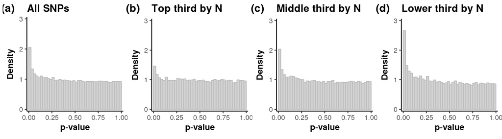

```r
# Demo on a small subset of SNPs first (remove this later)
bmi <- bmi[sample(1:nrow(bmi), 100000),]

# First for the sample size covariate (N)
strat_hist(bmi, pval="p_value", covariate="N", maxy=3)
```

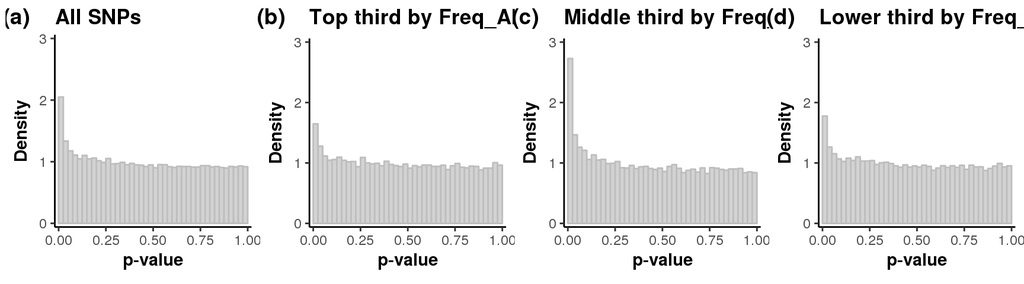

```r
# Next for the MAF covariate (Freq_Allele1_HapMapCEU)
strat_hist(bmi %>% filter(!is.na(Freq_Allele1_HapMapCEU)),
           pval="p_value", covariate="Freq_Allele1_HapMapCEU", maxy=3)
```

Next we’ll look at a scatter plot of p-values by the ranks of covariate values.

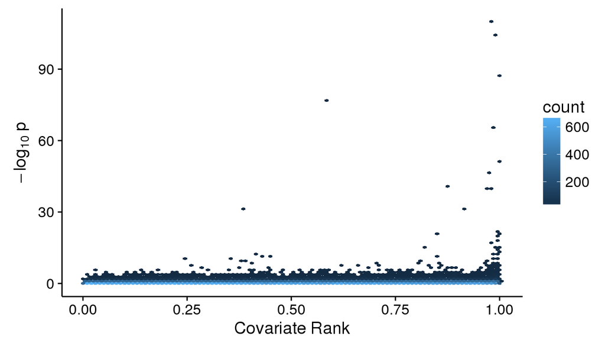

```r
# First for the sample size covariate (N)
rank_scatter(bmi, pval="p_value", covariate="N")
```

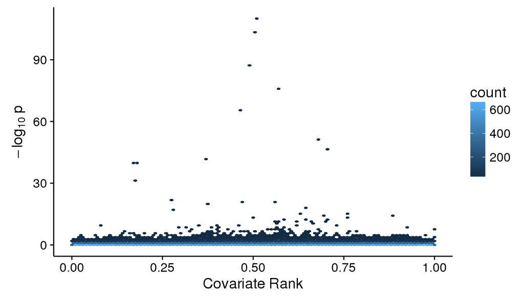

```r
# Next for the MAF covariate (Freq_Allele1_HapMapCEU)
rank_scatter(bmi, pval="p_value", covariate="Freq_Allele1_HapMapCEU")
```

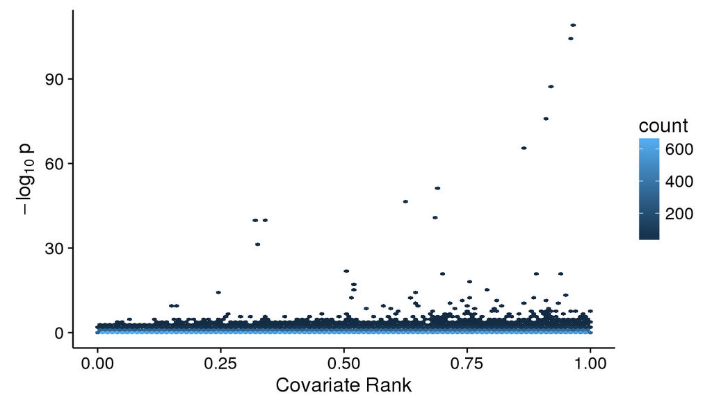

```r
# Take proximity to 0.5 as the actual covariate (according to previous plot)
bmi <- bmi %>%
        mutate(MAF.5=-abs(Freq_Allele1_HapMapCEU-0.5))
rank_scatter(bmi, pval="p_value", covariate="MAF.5")
```

#### Running benchmark methods

First, we’ll standardize the data frame to use the wrapper function. For now, we’ll assume that there is only a single ‘independent covariate’ for those methods that utilize this, and we’ll use the sample size (number of subjects with that SNP measured). **Still to-do: consider multiple covariates for methods that allow this.**

```r
bmi <- bmi %>%
        rename(pval = p_value,
               SE = stderr,
               effect_size = effect,
               ind_covariate = N) %>%
        mutate(zscore = effect_size/SE)
```

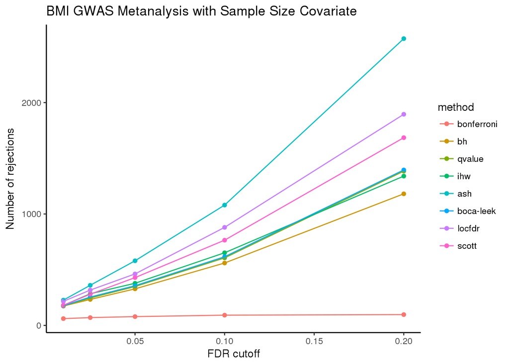

```r
cutoffs <- c(0.01, 0.025, 0.05, 0.10, 0.20)
resfile <- paste0(resdir, "bmi_results_",
                  nrow(bmi), ".RData")
if (!file.exists(resfile)){
  t1 <- proc.time()
  bmi_results <- run_benchmarks(dat=bmi, alphas=cutoffs, pvals=TRUE)
  save(bmi_results, file=resfile)
  message(paste0("Took ", round((proc.time()-t1)[3],1),
                 " seconds for ", nrow(bmi), " SNPs."))
}else{
  load(resfile)
}

# plot N rejects vs FDR cutoff
p <- ggplot(bmi_results$stats, aes(alpha, n_rejects, color=method)) +
  geom_point() +
  geom_line() +
  xlab("FDR cutoff") + ylab("Number of rejections") +
  ggtitle("BMI GWAS Metanalysis with Sample Size Covariate") +
  theme_classic()
print(p)
```

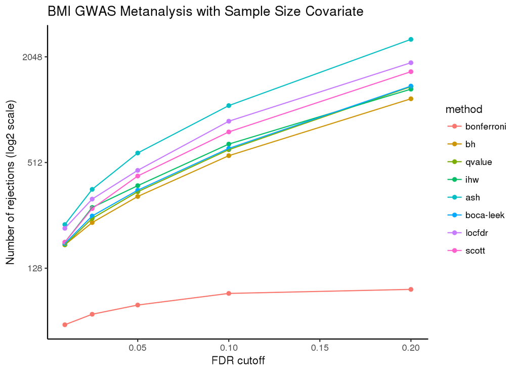

```r
# log-scale y axis
print(p + scale_y_continuous(trans="log2") +
        ylab("Number of rejections (log2 scale)"))
```

Next, we look beyond the number of rejections for each method and examine the overlap between them. We’ll use the Venn diagram alternative provided in the UpsetR package.

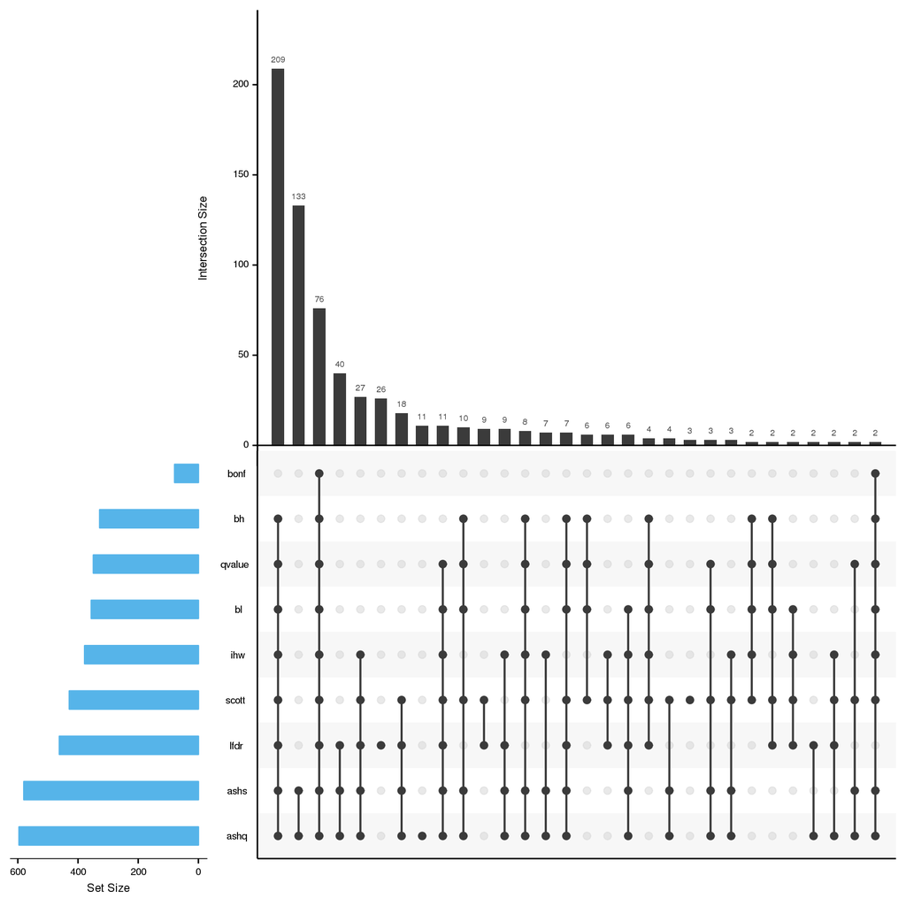

```r
sig_df <- bmi_results$pvals %>%
            mutate_all(function(x) 1*(x < alpha.cutoff))
upset(sig_df, nsets = 9, nintersects = 30, mb.ratio = c(0.5, 0.5),
      order.by = c("freq"), decreasing = c(TRUE),
      sets.bar.color = "#56B4E9")
```

And we’ll clean up the workspace before moving on to the next dataset.

```r
rm(bmi)
rm(bmi_results)
```

### GWAS for Asthma

[This study by Moffatt et al. (2010, NEJM)](http://www.nejm.org/doi/full/10.1056/NEJMoa0906312?query=TOC) performed a large GWAS on 10,365 people with asthma and 16,110 controls 23 individual studies.

#### Data Download

Let’s download the data from the Gabriel site. The second file contains metadata for the columns in the main data file.

```bash
curl -O "https://beaune.cng.fr/gabriel/gabriel_results.zip"
curl -O "https://beaune.cng.fr/gabriel/gabriel_results_description.xls"
```

Next we unzip the file and remove the zipped copy.

```bash
unzip gabriel_results.zip
rm gabriel_results.zip
```

Next, we’ll read in the unzipped `.txt` file and the results desription `.xls` file into R and verify that it contains the necessary inputs to run the FDR benchmark comparisons.

```r
# read in meta-data
meta <- read_xls(paste0(datdir, "gabriel_results_description.xls"))
head(meta)
```

```
## # A tibble: 6 x 4
##   num_col      variables
##     <dbl>          <chr>
## 1       1            Chr
## 2       2             rs
## 3       3       position
## 4       4       Allele_1
## 5       5       Allele_2
## 6       6 freq_all_1_min
## # ... with 2 more variables: description <chr>, X__1 <chr>
```

```r
dim(meta)
```

```
## [1] 276   4
```

```r
# read in data
asthma <- fread(paste0(datdir,
                "gabriel_asthma_meta-analysis_36studies_format_repository_NEJM.txt"),
                header=TRUE)
```

[output not shown]

```r
dim(asthma)
```

```
## [1] 567589    276
```

```r
# verify meta-data rows = data cols
nrow(meta) == ncol(asthma)
```

```
## [1] TRUE
```

```r
# remove study-specific columns
empty <- which(!is.na(meta$description))
asthma <- asthma %>%
            select(empty)
meta <- meta %>%
            slice(empty)

# remove SNPs with missing effect size/pvalues
asthma <- asthma %>%
            filter(!is.na(P_fix) & !is.na(theta_fix))

dim(asthma)
```

```
## [1] 546182     35
```

```r
head(asthma)
```

```
##   Chr         rs position Allele_1 Allele_2 freq_all_1_min freq_all_1_max
## 1   1  rs3094315   742429        A        G      0.7142857      0.8607306
## 2   1  rs3115860   743268        A        C      0.7083333      0.8986667
## 3   1  rs3115850   751010        C        T      0.7083333      0.8824363
## 4   1 rs12562034   758311        A        G      0.0654206      0.1303681
## 5   1 rs12124819   766409        A        G      0.6519608      0.8529412
## 6   1  rs4475691   836671        C        T      0.7816229      0.8947368
##   OR_fix ORl_fix ORu_fix   P_fix OR_ran ORl_ran ORu_ran   P_ran
## 1  1.040   0.982    1.10 0.18414  1.040   0.982    1.10 0.18414
## 2  0.992   0.920    1.07 0.84115  0.992   0.920    1.07 0.84115
## 3  0.750   0.408    1.38 0.35383  0.750   0.408    1.38 0.35383
## 4  1.010   0.949    1.08 0.70065  1.010   0.937    1.09 0.79423
## 5  0.970   0.895    1.05 0.45893  0.970   0.895    1.05 0.45893
## 6  1.010   0.950    1.07 0.80006  1.020   0.949    1.09 0.60748
##   no_studies_meta Chi2_hetero df_hetero P_hetero      Tau2        H   I2
```

[output cut: 27 more lines]

It looks like we have:

- `P_fix` and `P_ran`:p-values for fixed and random effect models
- `theta_fix` and `theta_ran`:effect size for fixed and random effect models
- `se_theta_fix` and `se_theta_ran`:standard error for fixed and random effect models
- additional covariates:
  - `no_studies_meta`: Number of studies included in the meta-analysis with this SNP
  - `freq_all_1_max` and `freq_all_1_min`: Maximum and Minimum Allele Frequency of Allele 1 across samples

for 546,182 SNPs.

#### Covariate Diagnostics

First, we will look at histograms of p-values stratified by covariate values. To stratify by continuous covariate values, we’ll use quantiles.

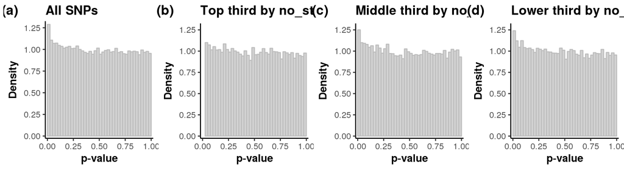

```r
# Demo on a small subset of SNPs first (remove this later)
asthma <- asthma[sample(1:nrow(asthma), 100000),]

# First for the sample size covariate (no_studies_meta)
strat_hist(asthma, pval="P_fix", covariate="no_studies_meta", maxy=1.3)
```

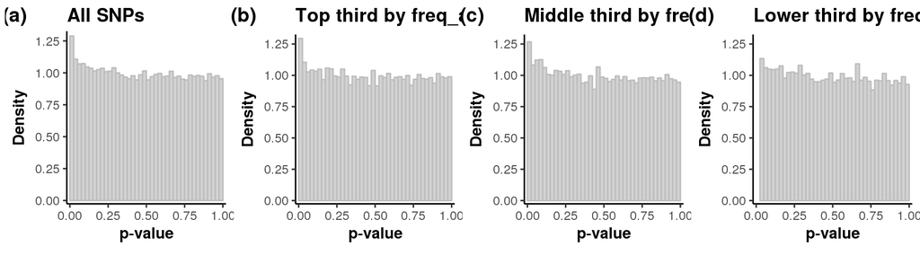

```r
# Next for the MAF covariate (freq_all_1_max)
strat_hist(asthma %>% filter(!is.na(freq_all_1_max)),
           pval="P_fix", covariate="freq_all_1_max", maxy=1.3)
```

Next we’ll look at a scatter plot of p-values by the ranks of covariate values.

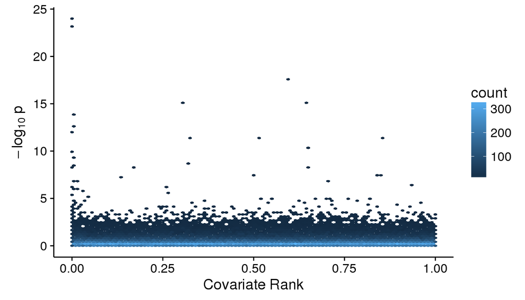

```r
# First for the sample size covariate (N)
rank_scatter(asthma, pval="P_fix", covariate="no_studies_meta")
```

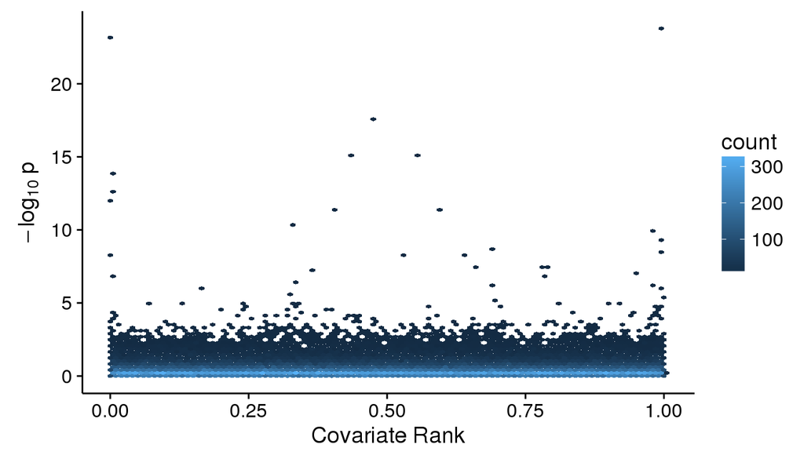

```r
# Next for the MAF covariate (freq_all_1_max)
rank_scatter(asthma, pval="P_fix", covariate="freq_all_1_max")
```

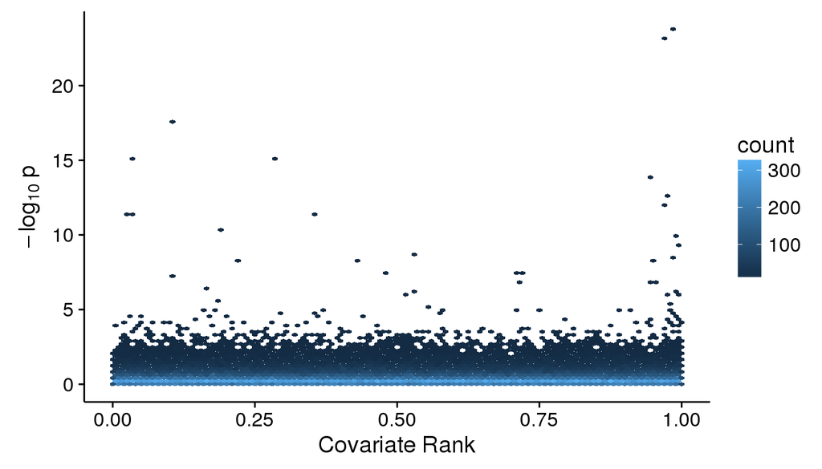

```r
# Take distance to 0.5 as the actual covariate
asthma <- asthma %>%
        mutate(MAF.5=abs(freq_all_1_max-0.5))
rank_scatter(asthma, pval="P_fix", covariate="MAF.5")
```

#### Running benchmark methods

First, we’ll standardize the data frame to use the wrapper function. For now, we’ll assume that there is only a single ‘independent covariate’ for those methods that utilize this, and we’ll use the sample size (number of studies with that SNP measured). We’ll also focus on the fixed effects tests first. **Still to-do: consider multiple covariates for methods that allow this.**

```r
asthma <- asthma %>%
        rename(pval = P_fix,
               SE = se_theta_fix,
               effect_size = theta_fix,
               ind_covariate = no_studies_meta) %>%
        mutate(zscore = effect_size/SE)
```

Now, we’ll run the `run_benchmarks` helper function on the `asthma` data frame for several alpha values and plot the results. This is fairly computationally intensive for some of the benchmark methods (since there are more than 500 thousand tests) and best run on a machine with lots of memory.

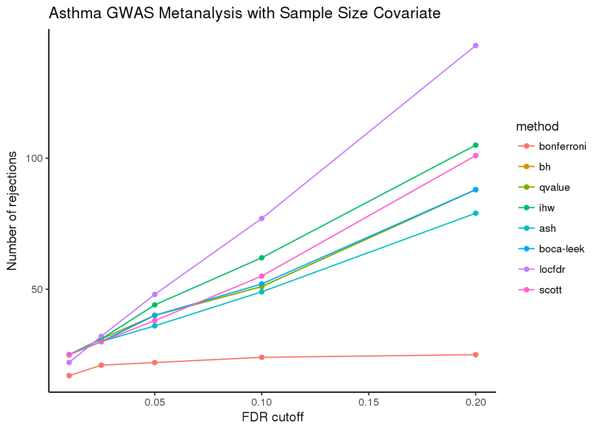

```r
# use same cutoffs as for the bmi study (defined above)
resfile <- paste0(resdir, "asthma_results_",
                  nrow(asthma), ".RData")
if (!file.exists(resfile)){
  t1 <- proc.time()
  asthma_results <- run_benchmarks(dat=asthma, alphas=cutoffs, pvals=TRUE)
  save(asthma_results, file=resfile)
  message(paste0("Took ", round((proc.time()-t1)[3],1),
                 " seconds for ", nrow(asthma), " SNPs."))
}else{
  load(resfile)
}

# plot N rejects vs FDR cutoff
p <- ggplot(asthma_results$stats, aes(alpha, n_rejects, color=method)) +
  geom_point() +
  geom_line() +
  xlab("FDR cutoff") + ylab("Number of rejections") +
  ggtitle("Asthma GWAS Metanalysis with Sample Size Covariate") +
  theme_classic()
print(p)
```

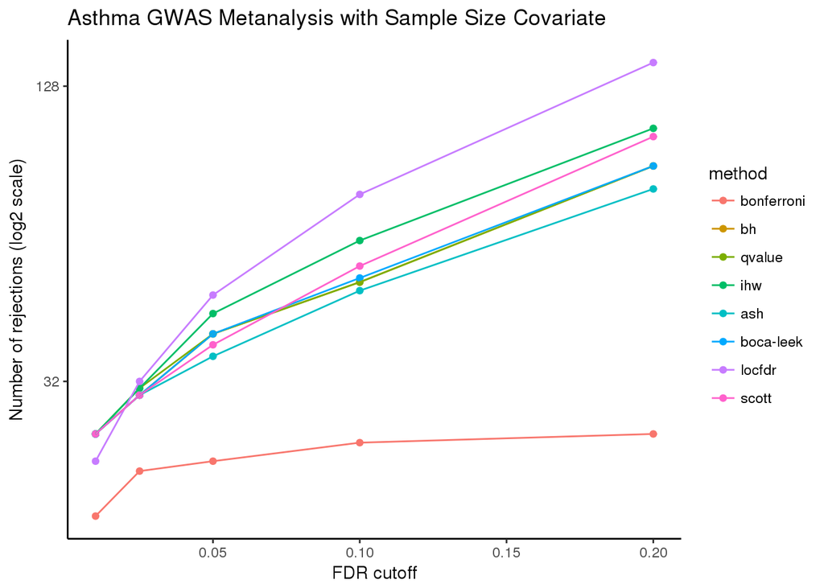

```r
# log-scale y axis
print(p + scale_y_continuous(trans="log2") +
        ylab("Number of rejections (log2 scale)"))
```

Next, we look beyond the number of rejections for each method and examine the overlap between them. We’ll use the Venn diagram alternative provided in the UpsetR package.

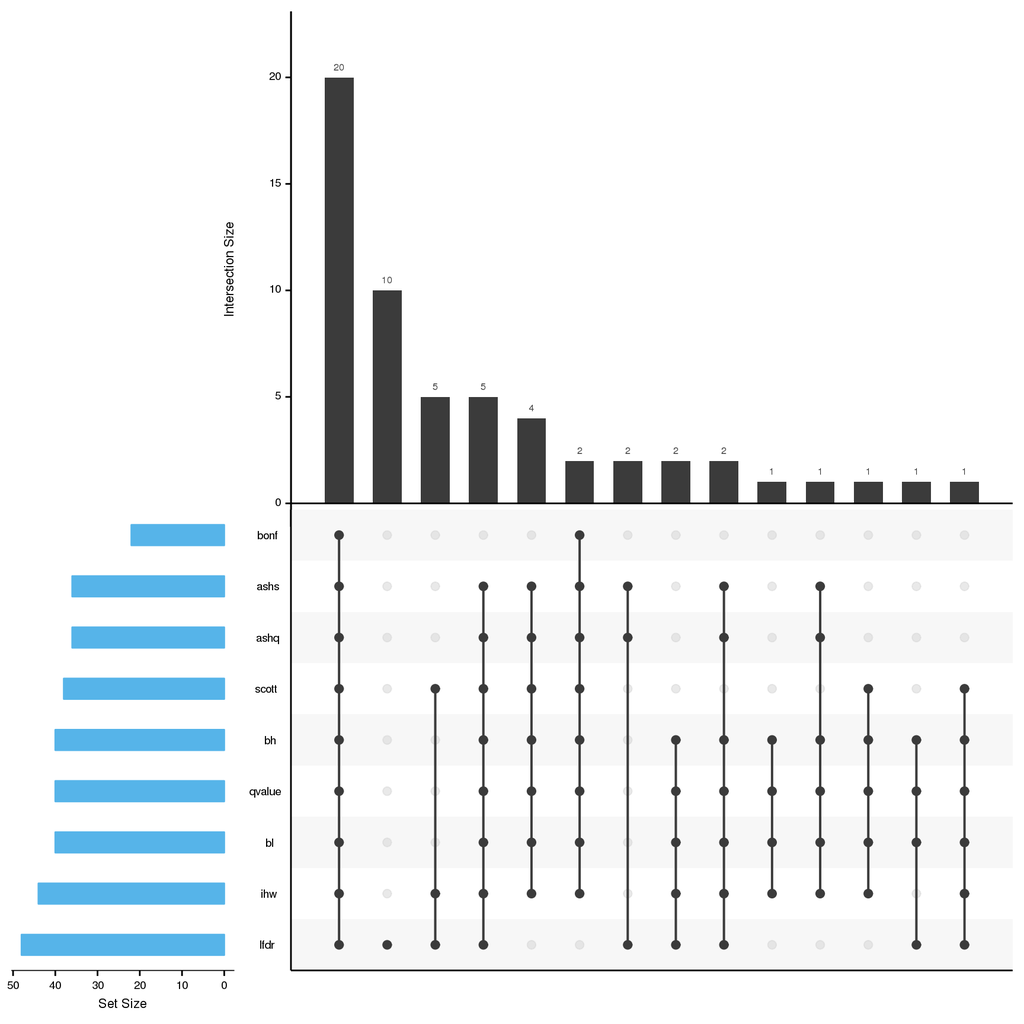

```r
sig_df <- asthma_results$pvals %>%
            mutate_all(function(x) 1*(x < alpha.cutoff))
upset(sig_df, nsets = 9, nintersects = 30, mb.ratio = c(0.5, 0.5),
      order.by = c("freq"), decreasing = c(TRUE),
      sets.bar.color = "#56B4E9")
```

And we’ll clean up the workspace before moving on to the next dataset.

```r
rm(asthma)
rm(asthma_results)
```

### GWAS for Lipid Levels

[This study by Willer et al. (2013, Nature Genetics)](http://www.nature.com/ng/journal/v45/n11/full/ng.2797.html) performed a large GWAS on 188,577 and measured blood lipid levels (as well as several cardiovascular traits).

#### Data Download

Let’s download the data from the University of Michigan site. The download page has a handy [metadata table](http://csg.sph.umich.edu//abecasis/public/lipids2013/) that describes the contents of the columns in the results files.

There are several types of results files to download (in terms of which phenotype to analyze):

- LDL Cholesterol
- HDL Cholesterol
- Triglycerides
- Total Cholesterol

As well as two types of analyses:

- Joint analyses of GWAS and Metabochip
- analysis of Metabochip

We would like to look at the joint analysis of GWAS + Metabochip since we’d like to look at all available SNPs (not just those that have previously shown a possible association with CVD). We could choose any or all of the traits, but I’ll go ahead and proceed with Triglycerides since I’m curious about the role of genetic variation on Triglyceride levels.

```bash
curl -O "http://csg.sph.umich.edu/abecasis/public/lipids2013/jointGwasMc_TG.txt.gz"
```

Next we uncompress the file.

```bash
gunzip jointGwasMc_TG.txt.gz
```

Next, we’ll read in the uncompressed `.txt` file into R and verify that it contains the necessary inputs to run the FDR benchmark comparisons.

```r
# read in data
trig <- fread(paste0(datdir, "jointGwasMc_TG.txt"), header=TRUE)
```

```
##
Read 8.6% of 2439432 rows
Read 19.3% of 2439432 rows
Read 21.7% of 2439432 rows
Read 33.2% of 2439432 rows
Read 43.0% of 2439432 rows
Read 53.3% of 2439432 rows
Read 54.9% of 2439432 rows
Read 69.3% of 2439432 rows
Read 77.9% of 2439432 rows
Read 86.5% of 2439432 rows
Read 99.2% of 2439432 rows
Read 2439432 rows and 10 (of 10) columns from 0.182 GB file in 00:00:33
```

```r
dim(trig)
```

```
## [1] 2439432      10
```

```r
head(trig)
```

```
##           SNP_hg18        SNP_hg19      rsid A1 A2   beta     se     N
## 1:  chr10:10000135   chr10:9960129 rs4747841  a  g 0.0020 0.0047 90263
## 2:  chr10:10000265   chr10:9960259 rs4749917  c  t 0.0020 0.0047 90263
## 3: chr10:100002729 chr10:100012739  rs737656  a  g 0.0094 0.0048 91013
## 4: chr10:100002880 chr10:100012890  rs737657  a  g 0.0094 0.0048 91013
## 5: chr10:100003553 chr10:100013563 rs7086391  c  t 0.0094 0.0061 91013
## 6: chr10:100003805 chr10:100013815  rs878177  c  t 0.0026 0.0049 91013
##    P-value Freq.A1.1000G.EUR
## 1: 0.75670            0.4908
## 2: 0.76120            0.4908
## 3: 0.06856            0.3206
## 4: 0.07994            0.3206
## 5: 0.11250            0.7810
## 6: 0.73140            0.6517
```

It looks like we have:

- `P_value`:p-value
- `beta`:effect size
- `SE`:standard error
- additional covariates:
  - `N`: The number of individuals analyzed for this marker.
  - `Freq.A1.1000G.EUR`: Frequency of allele A1 from 1000G EUR sample.

for 2,439,432 SNPs.

#### Covariate Diagnostics

First, we will look at histograms of p-values stratified by covariate values. To stratify by continuous covariate values, we’ll use quantiles.

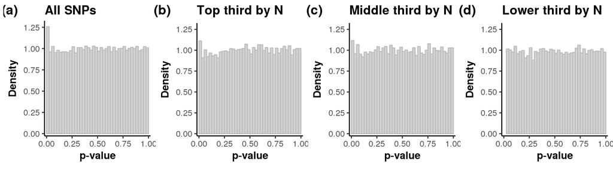

```r
# Demo on a small subset of SNPs first (remove this later)
trig <- trig[sample(1:nrow(trig), 100000),]

# First for the sample size covariate (no_studies_meta)
strat_hist(trig, pval="P-value", covariate="N", maxy=1.3)
```

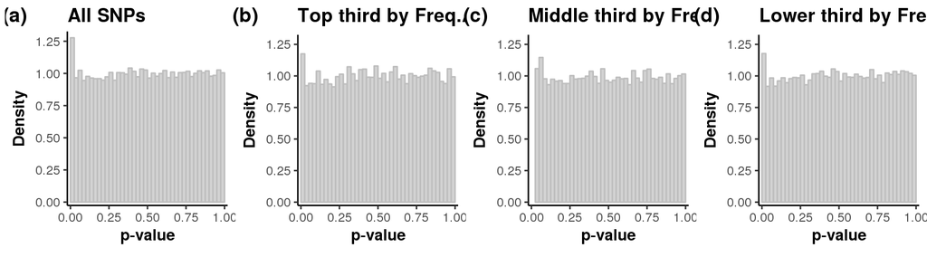

```r
# Next for the MAF covariate (Freq.A1.1000G.EUR)
strat_hist(trig %>% filter(!is.na(Freq.A1.1000G.EUR)),
           pval="P-value", covariate="Freq.A1.1000G.EUR", maxy=1.3)
```

Next we’ll look at a scatter plot of p-values by the ranks of covariate values.

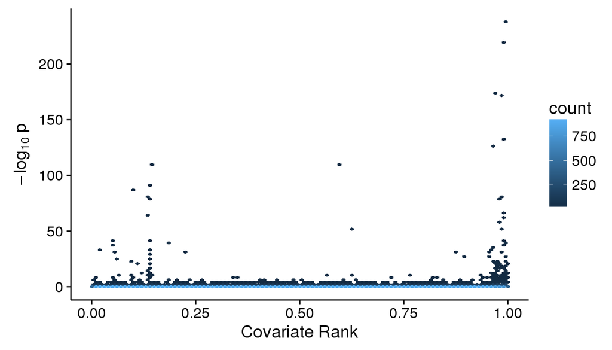

```r
# First for the sample size covariate (N)
rank_scatter(trig, pval="P-value", covariate="N")
```

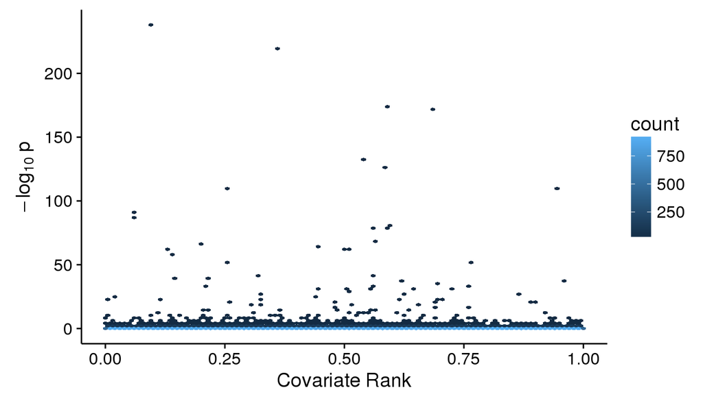

```r
# Next for the MAF covariate (Freq.A1.1000G.EUR)
rank_scatter(trig, pval="P-value", covariate="Freq.A1.1000G.EUR")
```

#### Running benchmark methods

First, we’ll standardize the data frame to use the wrapper function. For now, we’ll assume that there is only a single ‘independent covariate’ for those methods that utilize this, and we’ll use the sample size (number of individuals with that SNP measured). **Still to-do: consider multiple covariates for methods that allow this.**

Note that for this dataset, all reported effect sizes are positive. This is because the alleles (A1 and A2) have been ordered such that the direction of effect are consistent. Since Scott assumes that the Z-scores are standard normal, we can’t apply this method to a set of all positive Z-scores. To recover the direction of effect, we use the `Freq.A1.1000G.EUR` (allele frequency of A1) variable, and use it to determine whether `A1` (allele 1) is the reference allele or not. If the allele frequence of A1 is greater than 0.5, we consider it the reference allele. Then we’ll use the comparison of reference to minor as the positive direction. That is, if A2 was reference, then effect direction is negative. Otherwise it is positive. Since some of the SNPs are missing the reference allele information, we cannot determine their direction of effect and they will be removed.

```r
trig <- trig %>%
        rename(pval = "P-value",
               SE = se,
               effect_size = beta,
               ind_covariate = N)%>%
        mutate(zscore = effect_size/SE)

# add effect size
trig <- trig %>%
       mutate(A2.reference = Freq.A1.1000G.EUR < 0.5) %>%
       mutate(zscore = zscore * (1-2*A2.reference))

# remove SNPs with missing values for zscore (couldn't determine direction of
# effect)
trig <- trig %>%
  filter(!is.na(zscore))
```

```r
# use same cutoffs as for the bmi study (defined above)
resfile <- paste0(resdir, "trig_results_",
                  nrow(trig), ".RData")
if (!file.exists(resfile)){
  t1 <- proc.time()
  trig_results <- run_benchmarks(dat=trig, alphas=cutoffs, pvals=TRUE)
  save(trig_results, file=resfile)
  message(paste0("Took ", round((proc.time()-t1)[3],1),
                 " seconds for ", nrow(trig), " SNPs."))
}else{
  load(resfile)
}
```

```
## Running Bonferonni.
```

```
## Running BH.
```

```
## Running Storey's q.
```

```
## Running IHW.
```

```
## Running ash
```

```
## Due to absence of package REBayes, switching to EM algorithm
```

```
## Running Boca-Leek.
```

```
## At test #: 10000
```

```
## At test #: 20000
```

```
## At test #: 30000
```

```
## At test #: 40000
```

```
## At test #: 50000
```

```
## At test #: 60000
```

```
## At test #: 70000
```

```
## At test #: 80000
```

```
## At test #: 90000
```

```
## Running locfdr.
```

```
## Running Scott.
```

```
## Took 472.8 seconds for 92433 SNPs.
```

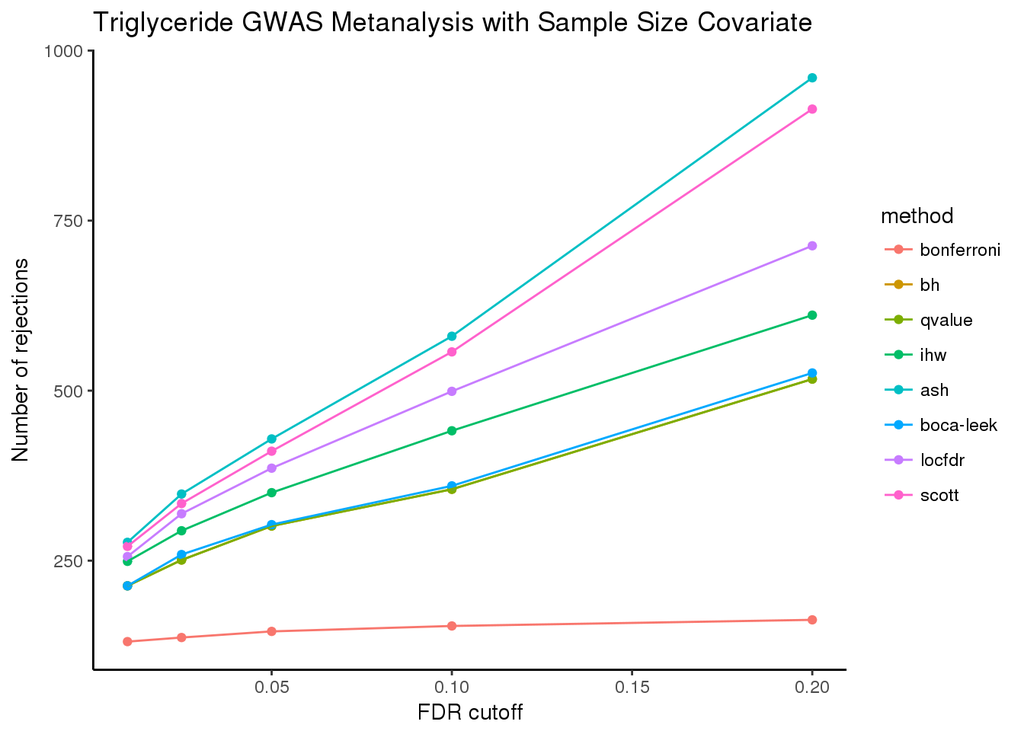

```r
# plot N rejects vs FDR cutoff
p <- ggplot(trig_results$stats, aes(alpha, n_rejects, color=method)) +
  geom_point() +
  geom_line() +
  xlab("FDR cutoff") + ylab("Number of rejections") +
  ggtitle("Triglyceride GWAS Metanalysis with Sample Size Covariate") +
  theme_classic()
print(p)
```

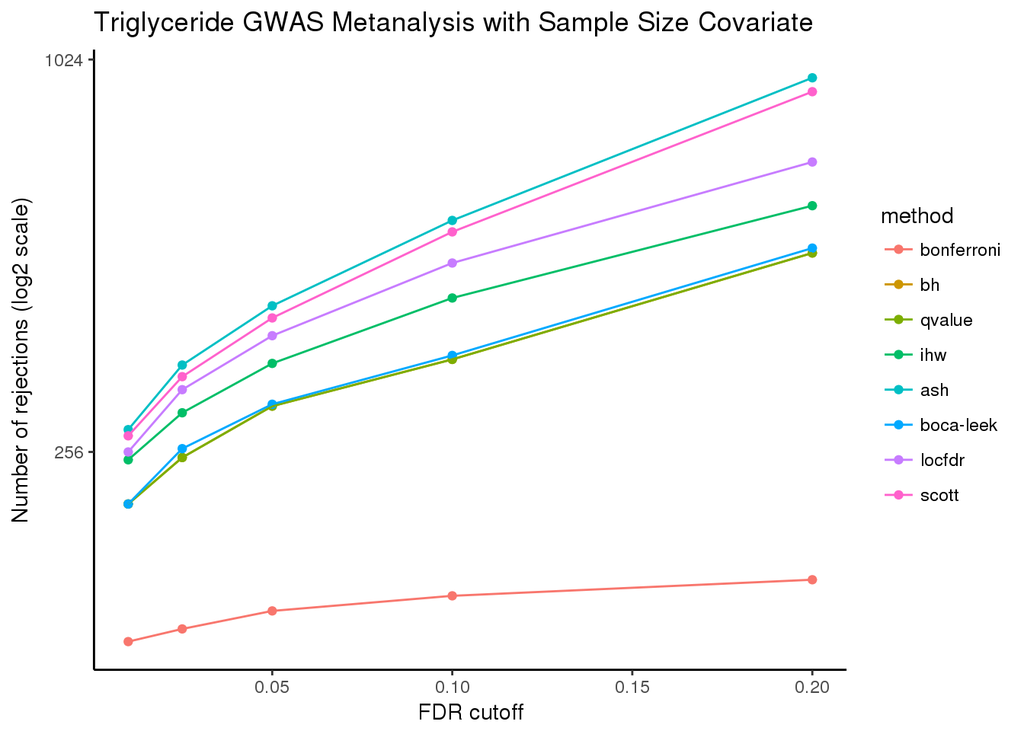

```r
# log-scale y axis
print(p + scale_y_continuous(trans="log2") +
        ylab("Number of rejections (log2 scale)"))
```

Next, we look beyond the number of rejections for each method and examine the overlap between them. We’ll use the Venn diagram alternative provided in the UpsetR package.

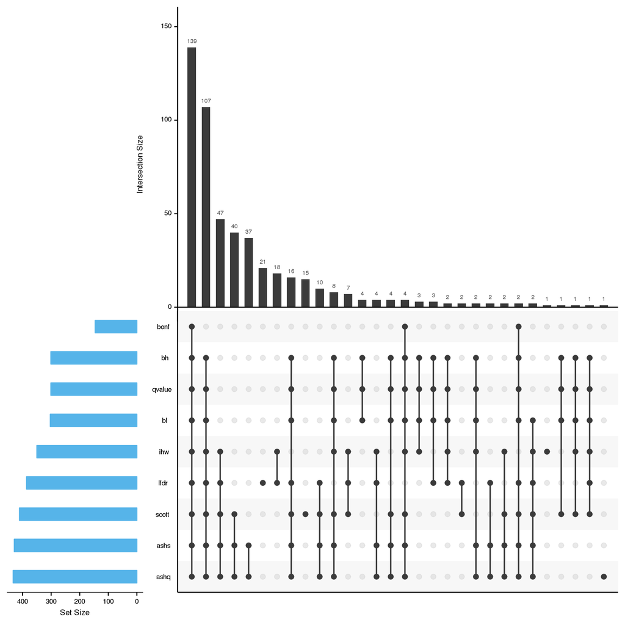

```r
sig_df <- trig_results$pvals %>%
            mutate_all(function(x) 1*(x < alpha.cutoff))
upset(sig_df, nsets = 9, nintersects = 30, mb.ratio = c(0.5, 0.5),
      order.by = c("freq"), decreasing = c(TRUE),
      sets.bar.color = "#56B4E9")
```

And we’ll clean up the workspace before moving on to the next dataset.

```r
rm(trig)
rm(trig_results)
```